# Tutorial 8: Data Mining Basics

Haowei, A0264683U

Due by October 24, 9:00 AM

```r
# load required packages
library(dplyr)
library(tidyr)
library(car) # for linearHypothesis()
library(ggplot2) # optional. we expect you to know base graphics, but allow ggplot if you find it easier
library(psych) # for pairs.panels()
library(factoextra) # for fviz_cluster()
library(wooldridge)
library(caret)
```

## Part Two: Assignment Submission

### Question 2 (Total 20 points)

- Dataset required: `gpa2` (wooldridge)

The dataset for this question is available at: https://rdrr.io/cran/wooldridge/man/gpa2.html, a public available dataset about class performance for the first fall semester in college, containing 4137 observations on 12 variables. Again, you need to install and load package `wooldridge` to conveniently load the data into your R workplace.

```r
data('gpa2')
```

Here are the variables in the dataset:

- `sat`: combined SAT score
- `tothrs`: total studying hours through fall semest
- `colgpa`: GPA after fall semester, in a 4.0 scale
- `athlete`: =1 if athlete
- `verbmath`: verbal/math SAT score
- `hsize`: size grad. class in high school, 100s
- `hsrank`: rank in grad. class in high school
- `hsperc`: high school percentile, from top
- `female`: =1 if female
- `white`: =1 if white
- `black`: =1 if black
- `hsizesq`: hsize^2

For the purpose of illustration, I create a new variable `scholarship` (granted scholarship after the first semester) which is equal to one if student’s class performance belongs to upper 20% of class comparable to his/her peers (curved) based on the GPA after the fall semester, i.e. `colgpa` is greater than 80th-quantile of `colgpa`, This would be a binary dependent variable we shall use in prediction and classification.

In this question, we will be interested in using the independent variables (student’s academic performance in SAT and high school) to classify and predict whether student will be granted scholarship or not after their first semester.

Here is a brief data description for all independent variables (using the `pairs.panels()` function from the `psych` package)

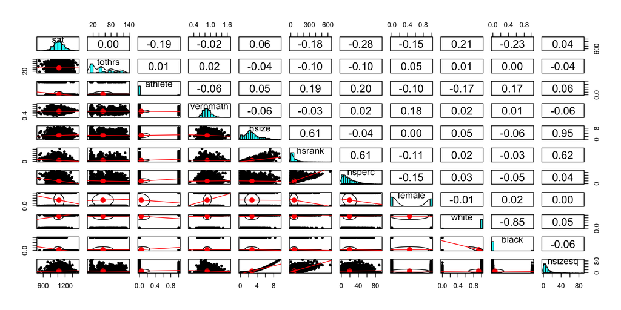

```r
# create a binary variable 'pass',
gpa2$scholarship = ifelse(gpa2$colgpa > quantile(gpa2$colgpa, 0.8), 1, 0)
# Selecting out the independent variables "X" included in our analysis.
gpa2X <- gpa2 %>% select(-c("colgpa", "scholarship"))
psych::pairs.panels(gpa2X, lm=TRUE)
```

Q2(a) Using the entire data set `gpa2`, let’s first start with the “kitchen sink” regression model `colgpa ~ . - colgpa - scholarship`, i.e. we include all independent variables on the RHS of the regression.

- using `linearHypothesis()` to jointly test if first semester’s GPA is affected by the size of graduating class in high school, i.e. `hsize = hsizesq = 0`. Draw your conclusion for the test; (2 points)
- run an automated backward model selection using `step()` function and interpret the coefficient of `tothrs`. Do you expect the sign of the coefficient before `tothrs`? (3 points)
- run an automated forward model selection and report the selected model. Does the forward model selection agree with the backward selection? (2 points)

```r
fit_full = lm(colgpa ~ . - scholarship, data = gpa2)
# Using 'linearHypothesis()'
linearHypothesis(model = fit_full, c("hsize = 0", "hsizesq = 0"))
```

```
## Linear hypothesis test
##
## Hypothesis:
## hsize = 0
## hsizesq = 0
##
## Model 1: restricted model
## Model 2: colgpa ~ (sat + tothrs + athlete + verbmath + hsize + hsrank +
##     hsperc + female + white + black + hsizesq + scholarship) -
##     scholarship
##
##   Res.Df    RSS Df Sum of Sq      F Pr(>F)
## 1   4127 1228.5
## 2   4125 1227.3  2    1.1858 1.9927 0.1365
```

```r
# Using Automated Backwards Model
step_back = step(fit_full, direction = 'backward')
```

```
## Start:  AIC=-5003
## colgpa ~ (sat + tothrs + athlete + verbmath + hsize + hsrank +
##     hsperc + female + white + black + hsizesq + scholarship) -
##     scholarship
##
##            Df Sum of Sq    RSS     AIC
## - white     1     0.065 1227.4 -5004.8
## - verbmath  1     0.363 1227.7 -5003.8
## - hsize     1     0.568 1227.9 -5003.1
## <none>                  1227.3 -5003.0
## - hsizesq   1     1.070 1228.4 -5001.4
## - black     1     6.199 1233.5 -4984.2
## - hsrank    1     6.467 1233.8 -4983.3
## - athlete   1     7.676 1235.0 -4979.2
## - tothrs    1    15.168 1242.5 -4954.2
## - female    1    20.220 1247.5 -4937.4
## - hsperc    1    40.752 1268.1 -4869.9
## - sat       1   146.913 1374.2 -4537.3
##
## Step:  AIC=-5004.78
## colgpa ~ sat + tothrs + athlete + verbmath + hsize + hsrank +
##     hsperc + female + black + hsizesq
##
##            Df Sum of Sq    RSS     AIC
## - verbmath  1     0.378 1227.8 -5005.5
## - hsize     1     0.564 1228.0 -5004.9
## <none>                  1227.4 -5004.8
## - hsizesq   1     1.067 1228.5 -5003.2
## - hsrank    1     6.500 1233.9 -4984.9
## - athlete   1     7.752 1235.1 -4980.7
## - tothrs    1    15.133 1242.5 -4956.1
## - black     1    17.611 1245.0 -4947.8
## - female    1    20.202 1247.6 -4939.2
## - hsperc    1    40.705 1268.1 -4871.8
## - sat       1   146.849 1374.2 -4539.3
##
## Step:  AIC=-5005.51
## colgpa ~ sat + tothrs + athlete + hsize + hsrank + hsperc + female +
##     black + hsizesq
##
```

[output cut: 11 more lines]

```
##
## Step:  AIC=-5005.6
## colgpa ~ sat + tothrs + athlete + hsrank + hsperc + female +
##     black + hsizesq
##
##           Df Sum of Sq    RSS     AIC
## <none>                 1228.3 -5005.6
## - hsizesq  1     0.655 1229.0 -5005.4
## - athlete  1     7.905 1236.2 -4981.1
## - hsrank   1     9.350 1237.7 -4976.2
## - tothrs   1    15.230 1243.6 -4956.6
## - black    1    17.474 1245.8 -4949.2
## - female   1    20.006 1248.3 -4940.8
## - hsperc   1    45.065 1273.4 -4858.5
## - sat      1   146.149 1374.5 -4542.5
```

```r
summary(step_back)
```

```
##
## Call:
## lm(formula = colgpa ~ sat + tothrs + athlete + hsrank + hsperc +
##     female + black + hsizesq, data = gpa2)
##
## Residuals:
##      Min       1Q   Median       3Q      Max
## -2.60569 -0.35419  0.01943  0.38512  1.96727
##
## Coefficients:
##               Estimate Std. Error t value Pr(>|t|)
## (Intercept)  1.2023232  0.0786603  15.285  < 2e-16 ***
## sat          0.0015026  0.0000678  22.162  < 2e-16 ***
## tothrs       0.0017305  0.0002419   7.154 9.91e-13 ***
## athlete      0.2175607  0.0422090   5.154 2.66e-07 ***
## hsrank      -0.0014337  0.0002558  -5.606 2.21e-08 ***
## hsperc      -0.0098397  0.0007996 -12.306  < 2e-16 ***
## female       0.1454128  0.0177342   8.200 3.19e-16 ***
## black       -0.2987997  0.0389914  -7.663 2.25e-14 ***
## hsizesq      0.0015405  0.0010383   1.484    0.138
## ---
## Signif. codes:  0 '***' 0.001 '**' 0.01 '*' 0.05 '.' 0.1 ' ' 1
##
## Residual standard error: 0.5455 on 4128 degrees of freedom
## Multiple R-squared:  0.3154, Adjusted R-squared:  0.3141
## F-statistic: 237.7 on 8 and 4128 DF,  p-value: < 2.2e-16
```

```r
# Using Automated Forwards Model
fit_intercept = lm(colgpa ~ 1, gpa2)
step_forward = step(fit_intercept, scope = ~ sat + tothrs + athlete + verbmath + hsize + hsrank + hsperc + female + white + black + hsizesq, direction = 'forward')
```

```
## Start:  AIC=-3454.11
## colgpa ~ 1
##
##            Df Sum of Sq    RSS     AIC
## + hsperc    1    329.49 1464.7 -4291.5
## + sat       1    299.71 1494.5 -4208.3
## + hsrank    1    201.80 1592.4 -3945.7
## + black     1     40.53 1753.7 -3546.6
## + tothrs    1     32.51 1761.7 -3527.8
## + white     1     31.67 1762.5 -3525.8
## + female    1     20.66 1773.5 -3500.0
## + athlete   1     14.97 1779.2 -3486.8
## + hsizesq   1      3.97 1790.2 -3461.3
## + hsize     1      1.46 1792.7 -3455.5
## <none>                  1794.2 -3454.1
## + verbmath  1      0.01 1794.2 -3452.1
##
## Step:  AIC=-4291.51
## colgpa ~ hsperc
##
##            Df Sum of Sq    RSS     AIC
## + sat       1   161.120 1303.6 -4771.6
## + black     1    52.249 1412.5 -4439.8
## + white     1    37.989 1426.7 -4398.2
## + tothrs    1    15.781 1448.9 -4334.3
## + hsrank    1    15.355 1449.3 -4333.1
## + female    1     3.610 1461.1 -4299.7
## + hsize     1     3.459 1461.2 -4299.3
## + hsizesq   1     1.829 1462.9 -4294.7
## <none>                  1464.7 -4291.5
## + verbmath  1     0.038 1464.7 -4289.6
## + athlete   1     0.024 1464.7 -4289.6
##
## Step:  AIC=-4771.61
## colgpa ~ hsperc + sat
##
##            Df Sum of Sq    RSS     AIC
## + female    1   21.2674 1282.3 -4837.7
## + tothrs    1   18.9565 1284.6 -4830.2
## + black     1   16.7293 1286.9 -4823.0
```

[output cut: 62 more lines]

```
## + hsizesq   1   0.65503 1228.3 -5005.6
## <none>                  1229.0 -5005.4
## + verbmath  1   0.41546 1228.6 -5004.8
## + hsize     1   0.13077 1228.9 -5003.8
## + white     1   0.07982 1228.9 -5003.7
##
## Step:  AIC=-5005.6
## colgpa ~ hsperc + sat + female + tothrs + black + hsrank + athlete +
##     hsizesq
##
##            Df Sum of Sq    RSS     AIC
## <none>                  1228.3 -5005.6
## + hsize     1   0.56737 1227.8 -5005.5
## + verbmath  1   0.38167 1228.0 -5004.9
## + white     1   0.07545 1228.3 -5003.9
```

```r
summary(step_forward)
```

```
##
## Call:
## lm(formula = colgpa ~ hsperc + sat + female + tothrs + black +
##     hsrank + athlete + hsizesq, data = gpa2)
##
## Residuals:
##      Min       1Q   Median       3Q      Max
## -2.60569 -0.35419  0.01943  0.38512  1.96727
##
## Coefficients:
##               Estimate Std. Error t value Pr(>|t|)
## (Intercept)  1.2023232  0.0786603  15.285  < 2e-16 ***
## hsperc      -0.0098397  0.0007996 -12.306  < 2e-16 ***
## sat          0.0015026  0.0000678  22.162  < 2e-16 ***
## female       0.1454128  0.0177342   8.200 3.19e-16 ***
## tothrs       0.0017305  0.0002419   7.154 9.91e-13 ***
## black       -0.2987997  0.0389914  -7.663 2.25e-14 ***
## hsrank      -0.0014337  0.0002558  -5.606 2.21e-08 ***
## athlete      0.2175607  0.0422090   5.154 2.66e-07 ***
## hsizesq      0.0015405  0.0010383   1.484    0.138
## ---
## Signif. codes:  0 '***' 0.001 '**' 0.01 '*' 0.05 '.' 0.1 ' ' 1
##
## Residual standard error: 0.5455 on 4128 degrees of freedom
## Multiple R-squared:  0.3154, Adjusted R-squared:  0.3141
## F-statistic: 237.7 on 8 and 4128 DF,  p-value: < 2.2e-16
```

Part i- linear hypothesis:  
The p-value of F-test is 0.1365 (>0.05), we do not have sufficient evidence to reject the null hypothesis.  
i.e. H0: unrestricted model (with `hsize` and `hsizesq`) is not significantly better than restricted model (without `hsize` and `hsizesq`) in terms of its explanatory power.  
Therefore, including `hsize` and `hsizesq` does not improves the explanatory power of the model to predict our dependent var `colgpa`.  
We are unable to conclude that first semester’s GPA is affected by the size of graduating class in high school From the F-test outputs, these two are not equivalent, yielding a F-statistic = 1.9927.  
Part ii- Automated Backwards Model Selection:  
Backward “step()”s final selected model is `colgpa ~ sat + tothrs + athlete + hsrank + hsperc + female + black + hsizesq`. Coefficient of `tothrs` is 0.0017305.  
Every unit increase of total studying hours through fall semester increases first semester’s GPA by 0.0017305, on average, given all other predictors constant.  
Yes, I expected the sign of the coefficient before `tothrs` as I feel that a higher effort put in by individuals in revision would lead to better overall grades.  
Part iii- Automated Forward Model Selection:  
Forward “step()”s final selected model is `colgpa ~ hsperc + sat + female + tothrs + black + hsrank + athlete + hsizesq`.  
Forward “step()”s final selected model agrees with backward AIC-based ‘step()’ selection.

Q2(b) From the correlation matrix at the very beginning, we can see that some of the independent variables are correlated with each other. Let’s try to summarize the data using principal component analysis (PCA). Use the `prcomp` function to conduct a PCA to summarize the information from the independent variables. (1 point)

- How many top PC’s we should retain if we’d like to have our PC’s represent more than 90% of variation in the data? (1 points)
- Extract the those PCs and pass them to `gpa2`. We’ll be using them as predictors later. (1 point)

Hint: Note that PCA only works well with *continuous* numeric variables.

```r
str(gpa2)
```

```
## 'data.frame':    4137 obs. of  13 variables:
##  $ sat        : int  920 1170 810 940 1180 980 880 980 1240 1230 ...
##  $ tothrs     : int  43 18 14 40 18 114 78 55 18 17 ...
##  $ colgpa     : num  2.04 4 1.78 2.42 2.61 ...
##  $ athlete    : int  1 0 1 0 0 0 0 0 0 0 ...
##  $ verbmath   : num  0.484 0.828 0.884 0.808 0.735 ...
##  $ hsize      : num  0.1 9.4 1.19 5.71 2.14 2.68 3.11 2.68 3.67 0.1 ...
##  $ hsrank     : int  4 191 42 252 86 41 161 101 161 3 ...
##  $ hsperc     : num  40 20.3 35.3 44.1 40.2 ...
##  $ female     : int  1 0 0 0 0 1 0 0 0 0 ...
##  $ white      : int  0 1 1 1 1 1 0 1 1 1 ...
##  $ black      : int  0 0 0 0 0 0 0 0 0 0 ...
##  $ hsizesq    : num  0.01 88.36 1.42 32.6 4.58 ...
##  $ scholarship: num  0 1 0 0 0 0 0 0 0 0 ...
##  - attr(*, "time.stamp")= chr "25 Jun 2011 23:03"
```

```r
gpa2 = na.omit(gpa2)
# excluding our resp
# running a principal component analysis (PCA) using 'prcomp()' function
# 'formula = ~ . -colgpa' in 'prcomp' helps us to removes our response variable 'wage' from the data to compute PCs.
# in addition, athlete, female, white, black, scholarship are binary variables (categorical). Conventional PCA is not recommended for data including categorical variables.
pca_gpa2 = prcomp(formula = ~ . -colgpa -athlete -female -white -black -scholarship, data = gpa2, center = TRUE, scale = TRUE)
# display the output of PCA on 'colgpa'
summary(pca_gpa2)
```

```
## Importance of components:
##                           PC1    PC2    PC3    PC4    PC5     PC6     PC7
## Standard deviation     1.5987 1.2252 1.0065 0.9872 0.8736 0.38518 0.20951
## Proportion of Variance 0.3651 0.2145 0.1447 0.1392 0.1090 0.02119 0.00627
## Cumulative Proportion  0.3651 0.5796 0.7243 0.8635 0.9725 0.99373 1.00000
```

```r
# Extract top 5 PCs and pass them to `gpa2`.
gpa2$pc1 = pca_gpa2$x[,"PC1"]
gpa2$pc2 = pca_gpa2$x[,"PC2"]
gpa2$pc3 = pca_gpa2$x[,"PC3"]
gpa2$pc4 = pca_gpa2$x[,"PC4"]
gpa2$pc5 = pca_gpa2$x[,"PC5"]

# or by extracting using a loop
#for (k in c(1:5)) {
#  gpa2[ , paste0("pc", k)] = gpa2_pca$x[,k]
#}
```

We should retain top 5 PCs if we’d like to have our PC’s represent more than 90% of variation in the data.

Q2(c) On the entire data `gpa2`, use a logistic classifier for `scholarship` with the top the five principal components. Which coefficients are statistically significant? (2 points) Using your trained logit classifier with those five PCs, call `predict(<glm_object>, type='response')` to ask the model to predict the probability of getting a scholarship after the first semester in college. Let’s make our rule to define the *predicted value* of `scholarship`: one if the predicted probability is >=0.50; zero if <0.50. Pass the binary predictions to a variable named `pred_scholarship` in `gpa2`. How many “Yes” (positives) and “No” (negatives) predictions did the model make? (3 points)

```r
# General linear model
pcafit = glm(scholarship ~ pc1 + pc2 + pc3 + pc4 + pc5, data = gpa2, family = binomial)
summary(pcafit)
```

```
##
## Call:
## glm(formula = scholarship ~ pc1 + pc2 + pc3 + pc4 + pc5, family = binomial,
##     data = gpa2)
##
## Deviance Residuals:
##     Min       1Q   Median       3Q      Max
## -1.9992  -0.6372  -0.3765  -0.1220   3.1821
##
## Coefficients:
##             Estimate Std. Error z value Pr(>|z|)
## (Intercept) -2.01373    0.06286 -32.035  < 2e-16 ***
## pc1          0.49882    0.04134  12.067  < 2e-16 ***
## pc2          1.14435    0.05358  21.356  < 2e-16 ***
## pc3         -0.14636    0.04515  -3.242  0.00119 **
## pc4          0.21956    0.04706   4.666 3.07e-06 ***
## pc5          0.07610    0.06184   1.231  0.21848
## ---
## Signif. codes:  0 '***' 0.001 '**' 0.01 '*' 0.05 '.' 0.1 ' ' 1
##
## (Dispersion parameter for binomial family taken to be 1)
##
##     Null deviance: 4100.1  on 4136  degrees of freedom
## Residual deviance: 3202.9  on 4131  degrees of freedom
## AIC: 3214.9
##
## Number of Fisher Scoring iterations: 6
```

```r
# Predict
# predict(pcafit, type = 'response')
gpa2$`pred_scholarship` = ifelse((predict(pcafit, type = 'response')) >= 0.5, 1,0)

# Counting number of positive and negative predictions
gpa2 %>% count(pred_scholarship == 1)
```

```
##   pred_scholarship == 1    n
## 1                 FALSE 3761
## 2                  TRUE  376
```

Coefficients of `pc1`, `pc2`, `pc3` and `pc4` are statistically significant as their p-values are <0.05, which suggests that there is sufficient evidence to reject the null hypothesis that the coefficients of `pc1`, `pc2`, `pc3` and `pc4`are statistically zero. The p-value for `pc5` is 0.21848 > 0.05, which suggests that there is insufficient evidence to reject the null hypothesis that the coefficient of `pc5` is statistically zero.

Number of positive predictions: 376  
Number of negative predictions: 3761

Q2(d) Finally, let’s manually construct a classification matrix using `table()` function in base R rather than `caret::confusionMatrix()` to evaluate our logistic classifier.

Use `table(x1, x2)` with both your model’s “Scholarship” predictions and the actual observed `scholarship` values (ignoring that we actually created `scholarship` at the first place). I recommend using the same convention in the lecture slides, where we have observed values on the columns and model prediction on the rows. *We say “granted a scholarship” as a positive event.* (4 points)

- How many True Positives are there?
- How many True Negatives are there?
- How many False Positives are there?
- How many False Negatives are there?
- What is the model’s overall classification accuracy?
- What is the model’s sensitivity?
- What is the model’s precision?
- What is the model’s specificity?

Note: show the formula how you computed each quantity above.

```r
# Using confusionMatrix()
#gpa2$pred_scholarship = factor(gpa2$pred_scholarship, labels = c('No Scholarship', 'Scholarship'))
#gpa2$scholarship = factor(gpa2$scholarship, labels = c('No Scholarship', 'Scholarship'))
#cm = confusionMatrix(gpa2$pred_scholarship, gpa2$scholarship, positive = 'Scholarship')
#print(cm)

# Using table
gpa2$pred_scholarship = factor(gpa2$pred_scholarship, labels = c('No Scholarship', 'Scholarship'))
gpa2$scholarship = factor(gpa2$scholarship, labels = c('No Scholarship', 'Scholarship'))
table(gpa2$pred_scholarship,gpa2$scholarship)
```

```
##
##                  No Scholarship Scholarship
##   No Scholarship           3199         562
##   Scholarship               125         251
```

```r
TP = 251
TN = 3199
FP = 125
FN = 562

# Calculation for accuracy
(TP+TN)/(TP+FN+FP+TN)
```

```
## [1] 0.8339376
```

```r
# Calculation for sensitivity
TP/(TP+FN)
```

```
## [1] 0.3087331
```

```r
# Calculation for precision
TP/(TP+FP)
```

```
## [1] 0.6675532
```

```r
# Calculation for specificity
TN/(FP+TN)
```

```
## [1] 0.9623947
```

There are 251 True Positives.  
There are 3199 True Negatives.  
There are 125 False Positives.  
There are 562 False Negatives.  
The model’s overall classification accuracy is 0.8339376.  
The model’s sensitivity is 0.3087331.  
The model’s precision is 0.6675532.  
The model’s specificity is 0.9623947.

Q2(e) Successfully debug and produce an HTML for submission. (1 point)